# R Visualization Exercises

Programming for Data Science Bootcamp

# Import Libraries

```r
library(vctrs)
```

```r
library(tidyverse)
```

# Get Data

See [info on the `mpg` dataset](https://ggplot2.tidyverse.org/reference/mpg.html).

```r
head(mpg)
```

A tibble: 6 × 11

| manufacturer <chr> | model <chr> | displ <dbl> | year <int> | cyl <int> | trans <chr> | drv <chr> | cty <int> | hwy <int> | fl <chr> | class <chr> |
| --- | --- | --- | --- | --- | --- | --- | --- | --- | --- | --- |
| audi | a4 | 1.8 | 1999 | 4 | auto(l5) | f | 18 | 29 | p | compact |
| audi | a4 | 1.8 | 1999 | 4 | manual(m5) | f | 21 | 29 | p | compact |
| audi | a4 | 2.0 | 2008 | 4 | manual(m6) | f | 20 | 31 | p | compact |
| audi | a4 | 2.0 | 2008 | 4 | auto(av) | f | 21 | 30 | p | compact |
| audi | a4 | 2.8 | 1999 | 6 | auto(l5) | f | 16 | 26 | p | compact |
| audi | a4 | 2.8 | 1999 | 6 | manual(m5) | f | 18 | 26 | p | compact |

# Exercise 1

Run `mpg %>% ggplot()` what do you see?

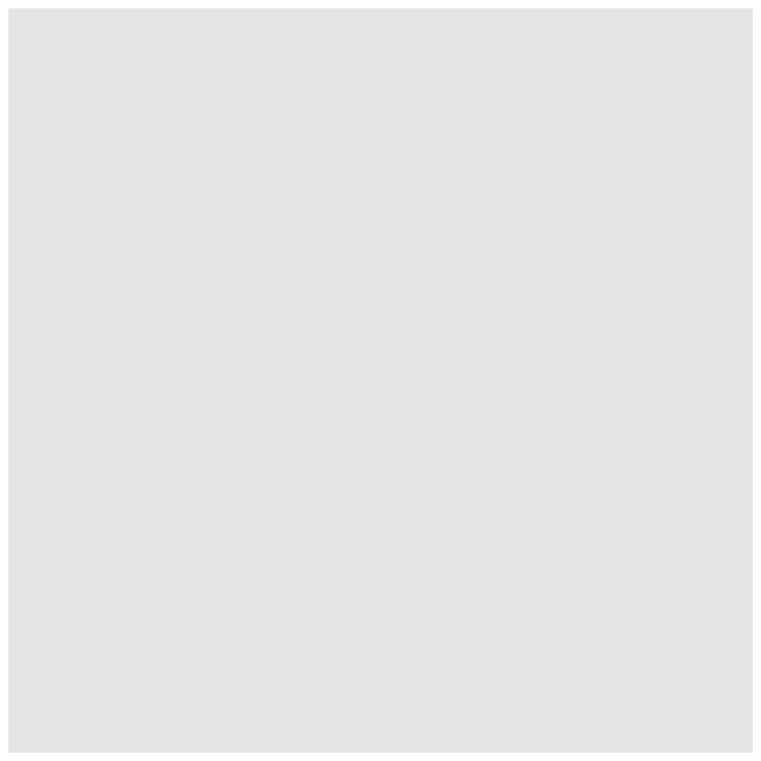

```r
mpg %>% ggplot()
```

# Exercise 2

Make a scatter plot of `hwy` vs. `cyl` in the `mpg` data set.

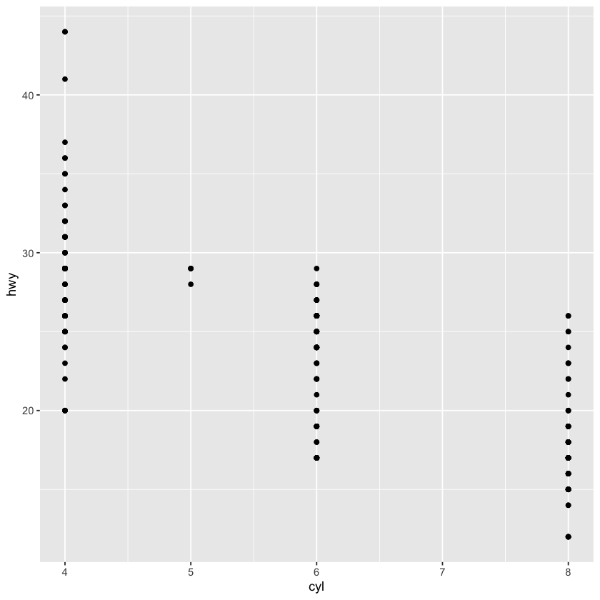

```r
mpg %>%
    ggplot(aes(x = cyl, y = hwy)) +
      geom_point()
```

`aes` is actually a value for the `mapping` argument.

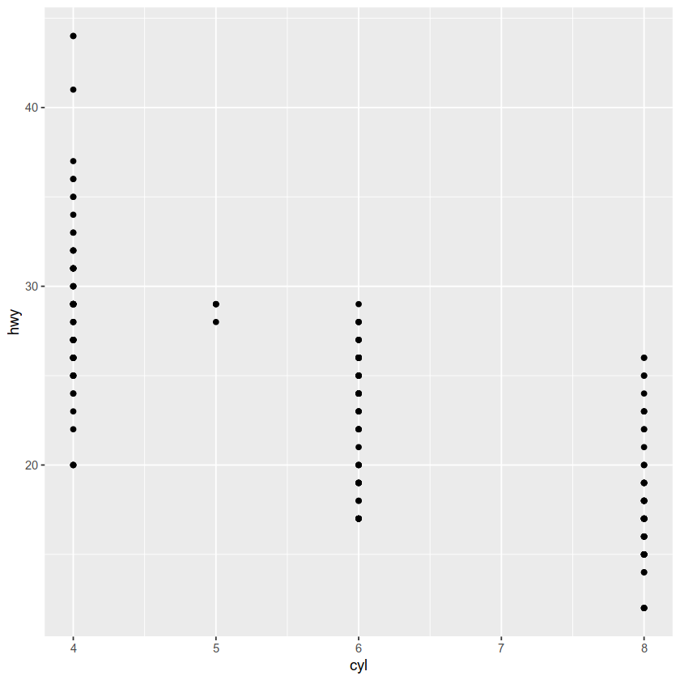

```r
mpg %>%
    ggplot(mapping = aes(x = cyl, y = hwy)) +
      geom_point()
```

`aes` can also be treated as a separate operation.

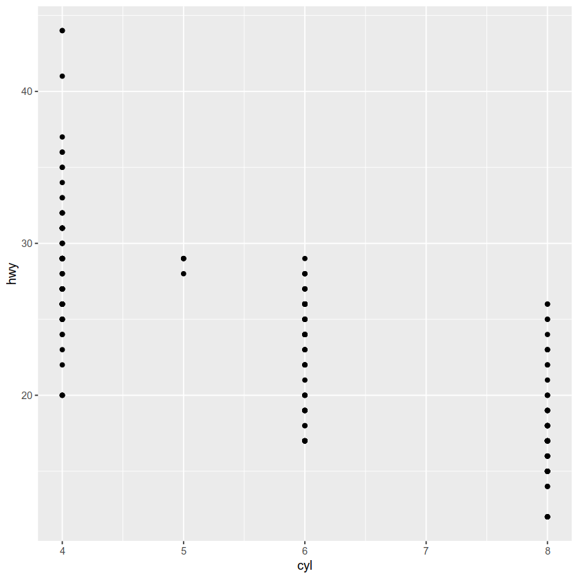

```r
mpg %>%
    ggplot() +
    aes(x = cyl, y = hwy) +
    geom_point()
```

# Exercise 3

What happens if you make a scatter plot of `class` vs `drv`?

Why is the plot not useful?

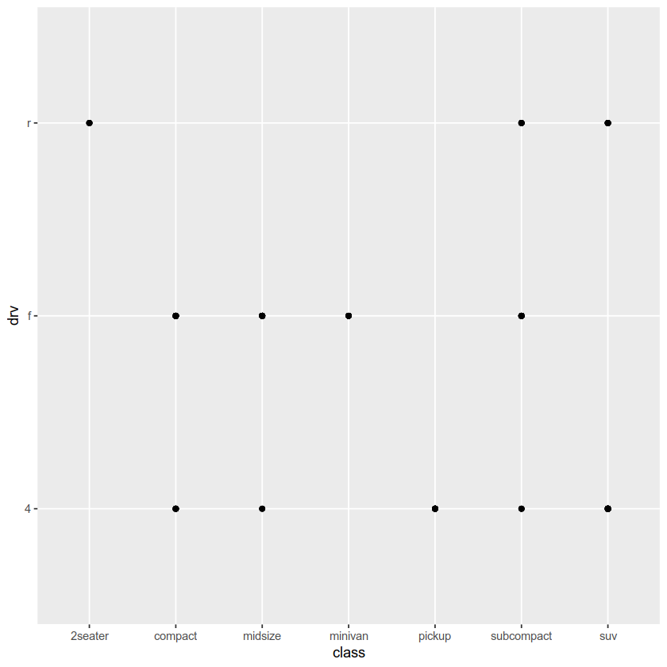

```r
mpg %>%
    ggplot(aes(x = class, y = drv)) +
    geom_point()
```

The resulting scatterplot has only a few points.

A scatter plot is not a useful display of these variables since **both `drv` and `class` are categorical variables**.

👉 Categorical variables typically take a small number of values, so there are a limited number of unique combinations of $(x, y)$ values that can be displayed.

👉 In this data, `drv` takes $3$ values and `class` takes $7$ values, meaning that there are only $21$ values that could be plotted on a scatterplot of `drv` vs. `class`.

👉 In this data, there $12$ values of (`drv`, `class`) are observed.

# Exercise 4

Plot the mathematical function $sin(x)/x$.

Hint: Use this to create your data and convert to a data frame or tibble:

```
x <- seq(-6 * pi, 6 * pi, length.out = 100)
```

```r
x <- seq(-6 * pi, 6 * pi, length.out = 100)
dat <- data.frame(x = x, y = sin(x)/x)
head(dat)
```

A data.frame: 6 × 2

|  | x <dbl> | y <dbl> |
| --- | --- | --- |
| 1 | -18.84956 | -3.898172e-17 |
| 2 | -18.46876 | -2.012385e-02 |
| 3 | -18.08796 | -3.815130e-02 |
| 4 | -17.70716 | -5.137086e-02 |
| 5 | -17.32636 | -5.765016e-02 |
| 6 | -16.94556 | -5.576687e-02 |

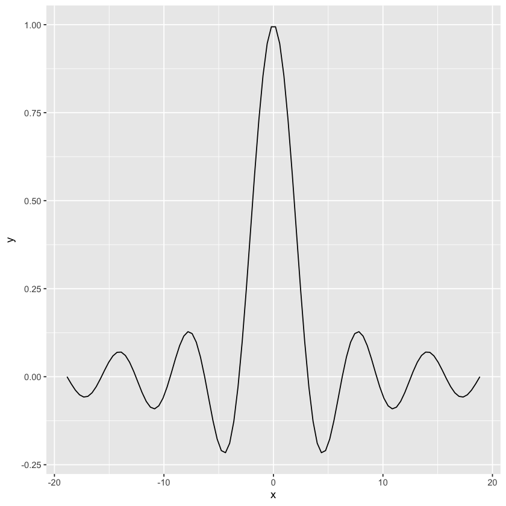

```r
ggplot(data = dat,
    mapping = aes(x = x, y = y)) +
    geom_line()
```

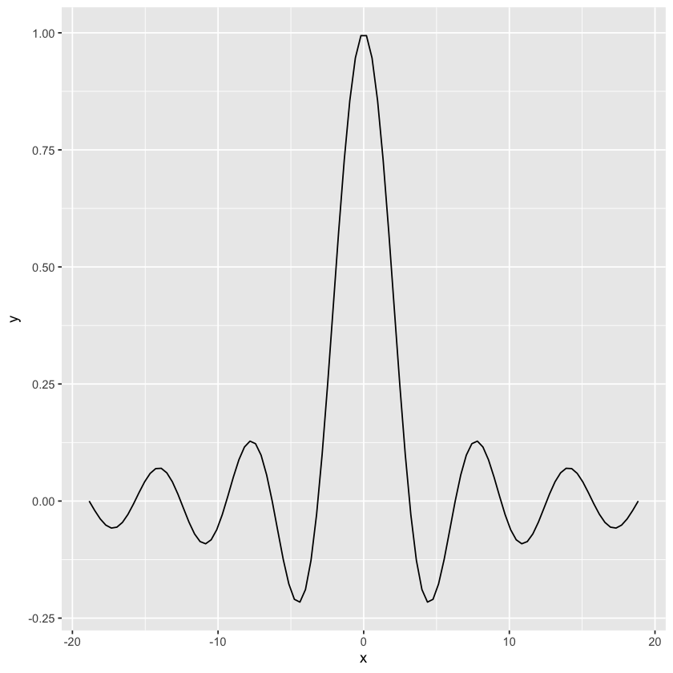

```r
dat %>%
    ggplot(aes(x = x, y = y)) +
    geom_line()
```

# Exercise 5

Plot the `cars` data set as a scatter plot using `speed` vs `dist`.

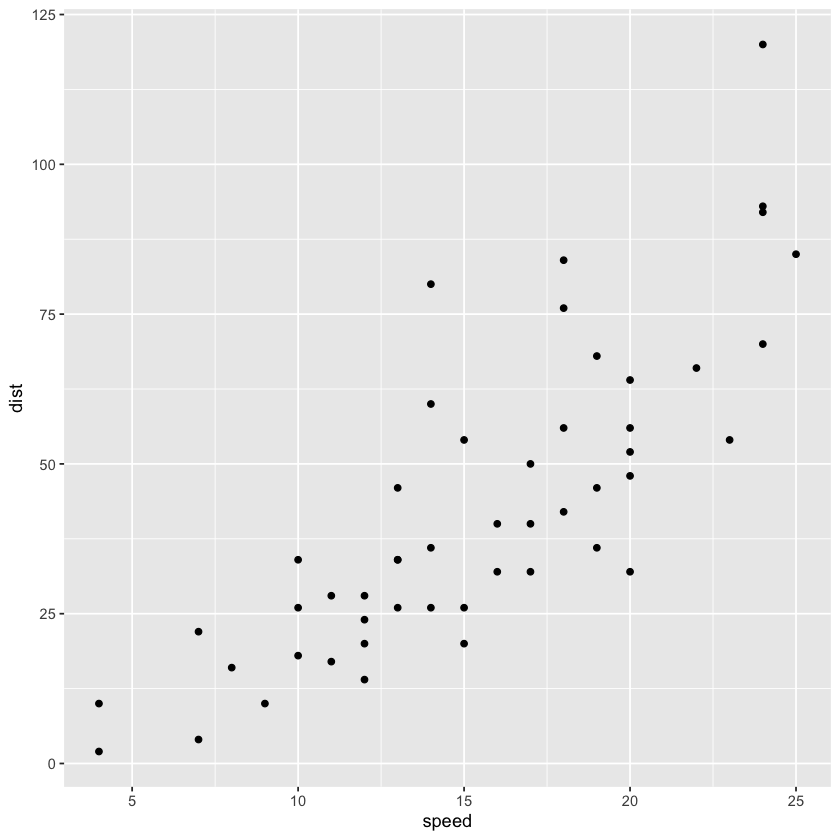

```r
cars %>%
    ggplot(aes(x = speed, y = dist)) +
    geom_point()
```

# Exercise 6

Create the same plot plot, this time using color to distinguish data points with distances taken to stop greater than $80$.

```r
head(cars)
```

A data.frame: 6 × 2

|  | speed <dbl> | dist <dbl> |
| --- | --- | --- |
| 1 | 4 | 2 |
| 2 | 4 | 10 |
| 3 | 7 | 4 |
| 4 | 7 | 22 |
| 5 | 8 | 16 |
| 6 | 9 | 10 |

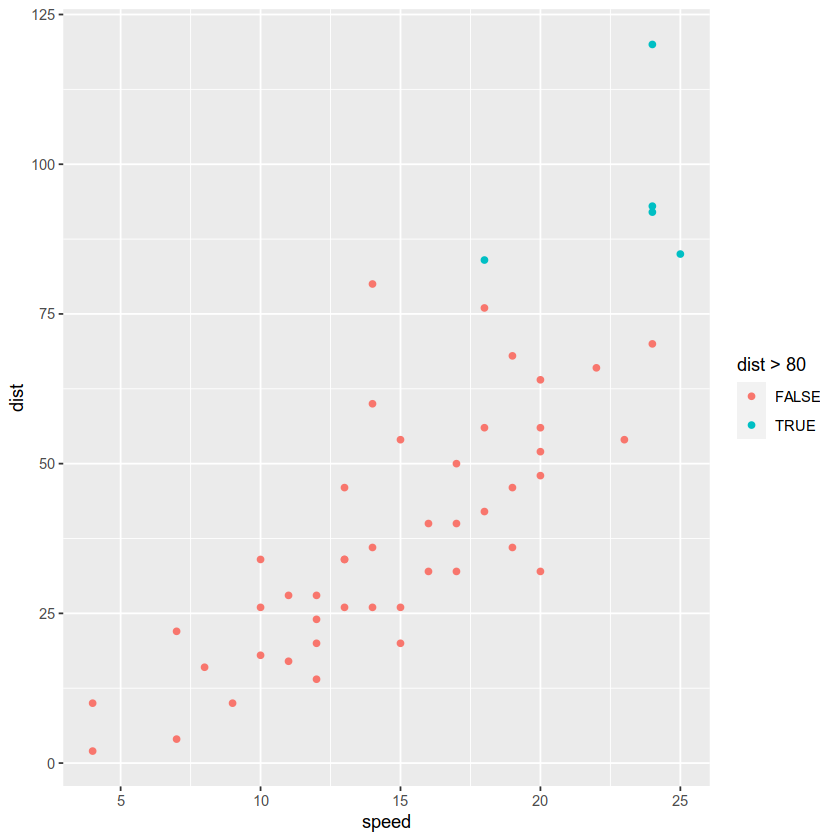

```r
cars %>%
    ggplot(aes(x = speed, y = dist)) +
    geom_point(mapping = aes(color = dist > 80))
```

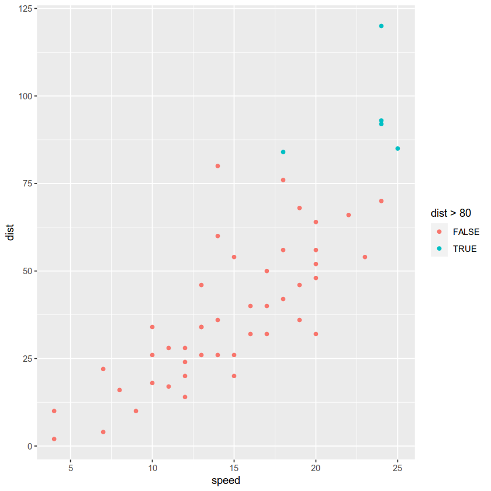

```r
cars %>%
    ggplot() +
    aes(x = speed, y = dist) +
    geom_point() +
    aes(color = dist > 80)
```

# Exercise 7

Change the plot so that values $> 80$ are in red and the other in blue.

Hint: Define the colors using a manual color scale in `scale_color_manual()`.

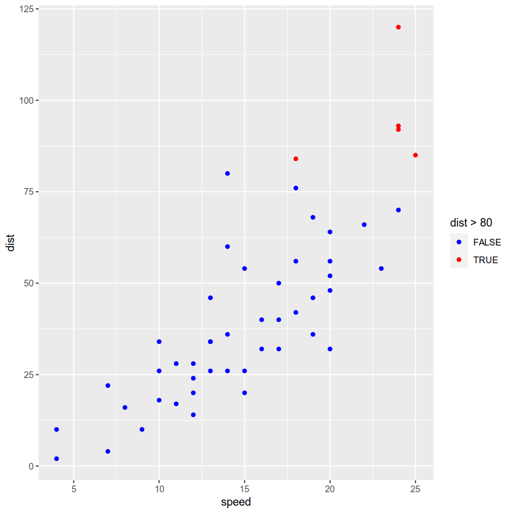

```r
cars %>%
    ggplot(aes(x = speed, y = dist)) +
    geom_point(mapping = aes(color = dist > 80)) +
    scale_color_manual(values = c("blue", "red"))
```

Another way, using `ifelse()`:

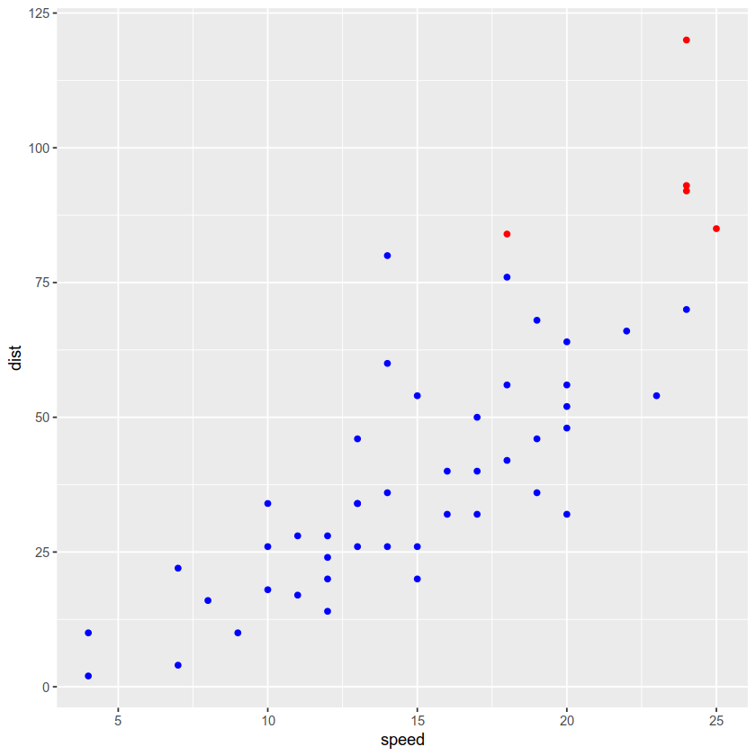

```r
cars %>%
    ggplot(aes(speed, dist)) +
    geom_point(color = ifelse(cars$dist > 80, 'red', 'blue'))
```

# Exercise 8

Add a second `geom` that produces a smoothed line.

Use `lm` as your smoothing method.

Hint: Add `geom_smooth()` to your graphic.

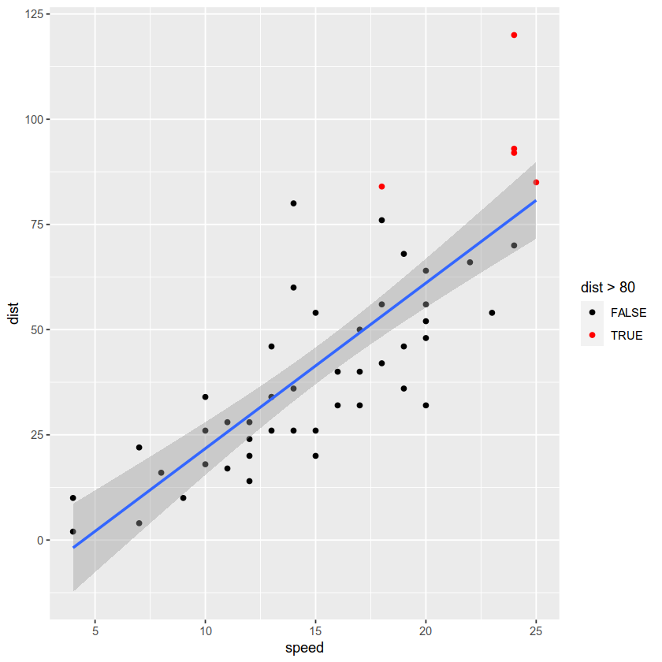

```r
cars %>%
    ggplot(aes(x = speed, y = dist)) +
      geom_point(aes(color = dist > 80)) +
      scale_color_manual(values = c("black", "red")) +
      geom_smooth(method = 'lm')
```

Smoothing method (function) to use includes: `lm`, `glm`, `gam`, `loess`, `rlm`.

`loess`: locally weighted smoothing

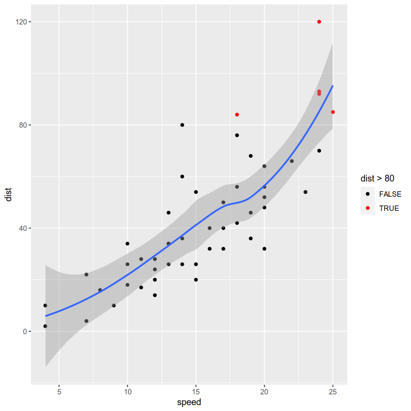

```r
cars %>%
    ggplot(aes(x = speed, y = dist)) +
      geom_point(aes(color = dist > 80)) +
      scale_color_manual(values = c("black", "red")) +
      geom_smooth(method = 'loess')
```

# Exercise 9

Plot histograms for `speed` and `dist` in `cars`.

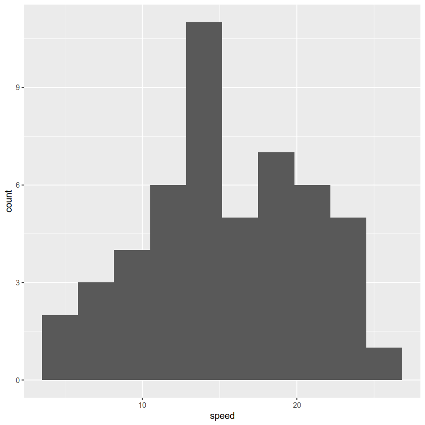

```r
cars %>%
    ggplot(aes(x = speed)) +
    geom_histogram(bins = 10)
```

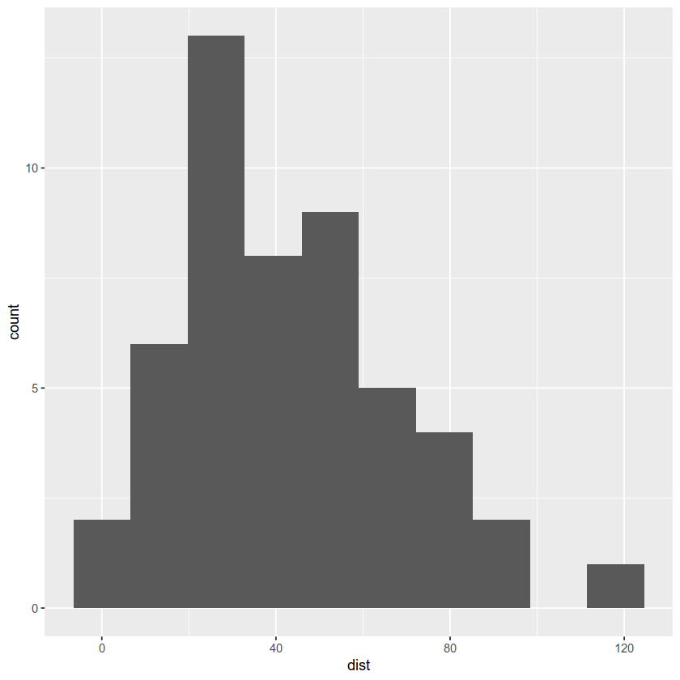

```r
cars %>%
    ggplot(aes(x = dist)) +
    geom_histogram(bins = 10)
```

# Exercise 10

Create a faceted plot of a scatterplot of `hwy` and `cty` of the `mpg` with `drv` as rows and `cyl` as cols.

What do the empty cells mean?

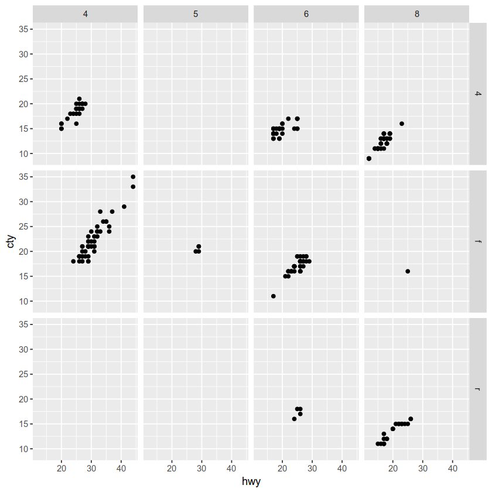

```r
mpg %>%
    ggplot() +
      geom_point(aes(x = hwy, y = cty)) +
      facet_grid(drv ~ cyl)
```

The empty cells (facets) in this plot are combinations of drv and cyl that have no observations.

These are the same locations in the scatter plot of drv and cyl that have no points.

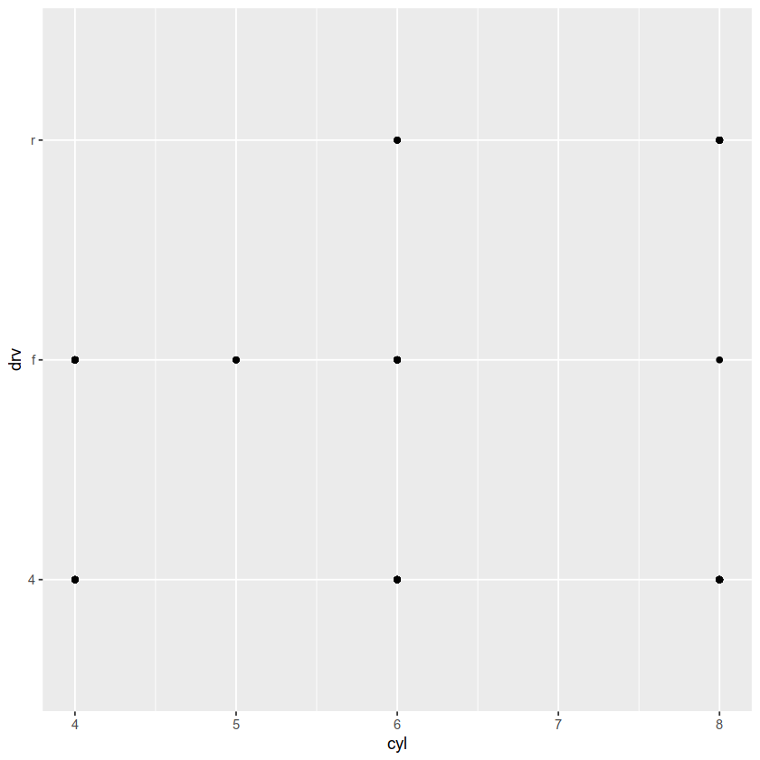

```r
mpg %>%
    ggplot() +
      geom_point(aes(y = drv, x = cyl))
```

Without faceting:

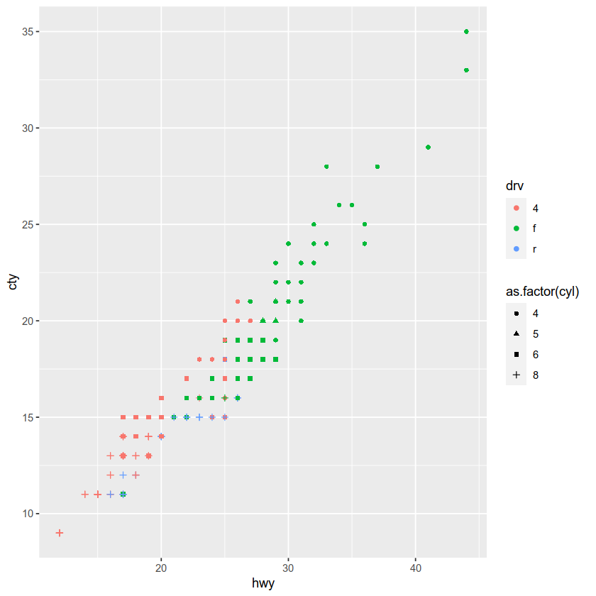

```r
mpg %>%
    ggplot() +
      geom_point(aes(x = hwy, y = cty,
                     color=drv,
                     shape=as.factor(cyl)))
```

# Exercise 11

Reproduce this graphic from the iris dataset:

[figure not shown]

Hint: This graphic uses two geometries, one title, and one theme function.

One of the geometries is `geom_density2d()` and the theme function is `theme_light()`.

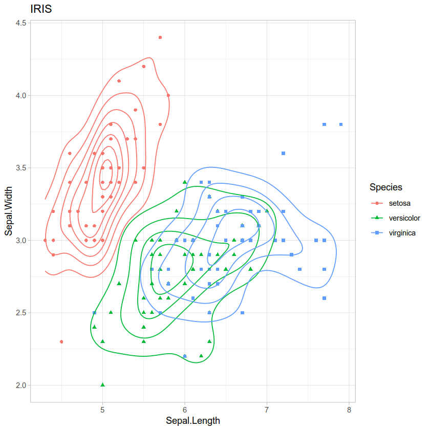

```r
iris %>%
  ggplot(aes(x = Sepal.Length, y = Sepal.Width, color = Species, shape = Species)) +
  geom_point() +
  geom_density2d() +
  ggtitle('IRIS') +
  theme_light()
```

# Exercise 12

Reproduce this graphc from the iris dataset:

[figure not shown]

Hints:

(1) Preprocess your data as follows:

```
{r}
iris %>%
  mutate(Species = 'ALL') %>%   # Create a copy of iris where Species has only 'ALL'
  bind_rows(iris)               # concatenate to the original iris
```

(2) This graphic uses faceting with `facet_wrap()` and theme function `theme_bw()`.

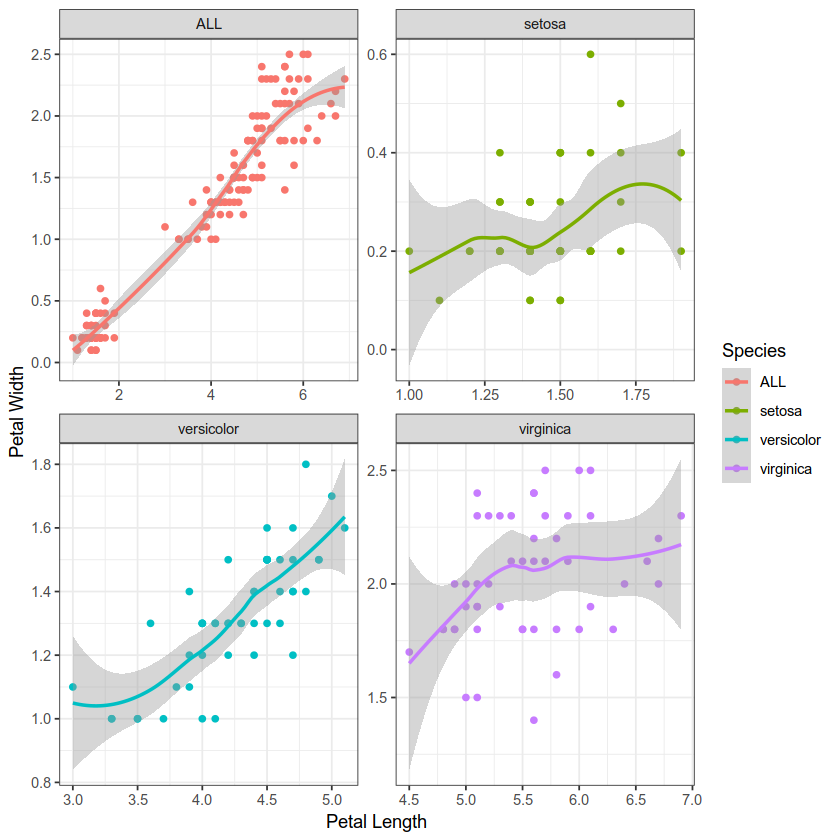

```r
iris %>%
  mutate(Species = 'ALL') %>%
  bind_rows(iris) %>%
  ggplot(aes(x = Petal.Length, y = Petal.Width, color = Species)) +
      geom_point() +
      geom_smooth(method = 'loess') +
      xlab('Petal Length') +
      ylab('Petal Width') +
      facet_wrap(~Species, scales = 'free') +
      theme_bw()
```

# Exercise 13

Reproduce this graphic using the mtcars dataset:

[figure not shown]

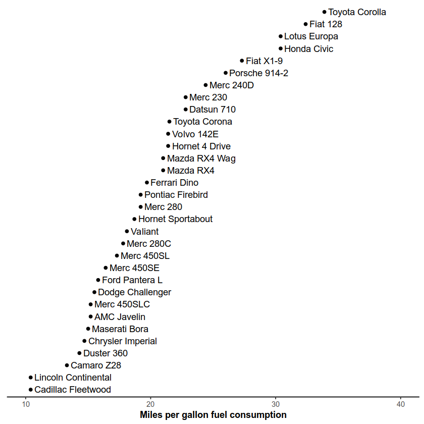

```r
mtcars %>%
  rownames_to_column() %>%
  mutate(rowname = forcats::fct_reorder(rowname, mpg)) %>%
  ggplot(aes(rowname, mpg, label = rowname)) +
  geom_point() +
  geom_text(nudge_y = .3, hjust = 'left') +
  coord_flip() +
  ylab('Miles per gallon fuel consumption') +
  ylim(10, 40) +
  theme_classic() +
  theme(plot.title = element_text(hjust = 0, size = 16),
        axis.title.x = element_text(face = 'bold'),
        axis.title.y = element_blank(),
        axis.text.y = element_blank(),
        axis.ticks.y = element_blank(),
        axis.line.y = element_blank())
```

# Exercise 14

Reproduce this graphic using the mtcars dataset:

[figure not shown]

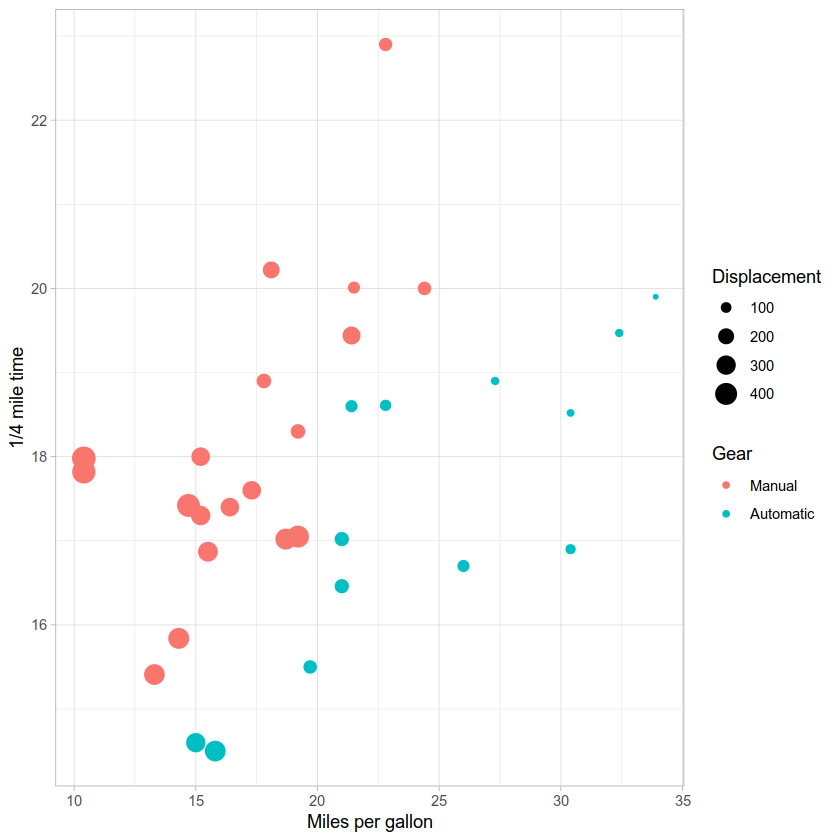

```r
mtcars %>%
  ggplot(aes(x = mpg, y = qsec, size = disp, color = as.factor(am))) +
  geom_point() +
  scale_colour_discrete(name  ="Gear",
                        breaks=c(0, 1),
                        labels=c("Manual", "Automatic")) +
  scale_size_continuous(name = 'Displacement') +
  xlab('Miles per gallon') +
  ylab('1/4 mile time') +
  theme_light()
```

# Exercise 15

Reproduce this image using the diamonds dataset:

[figure not shown]

https://www.r-exercises.com/wp-content/uploads/2018/02/ggplot-exercises-5.png

Process the data.

```r
diamonds2plot <- diamonds %>%
  group_by(cut, color) %>%
  # See note re .groups in the following
  summarize(price = mean(price), .groups = 'drop') %>%
  arrange(color, price) %>%
  ungroup() %>%
  mutate(id = row_number(),
         angle = 90 - 360 * (id - 0.5) / n())
```

Note the we add the `.groups = 'drop'` argument to `summarize()` to avoid this error message:

- `summarise()` has grouped output by 'cut'. You can override using the `.groups` argument.

Build the visualization.

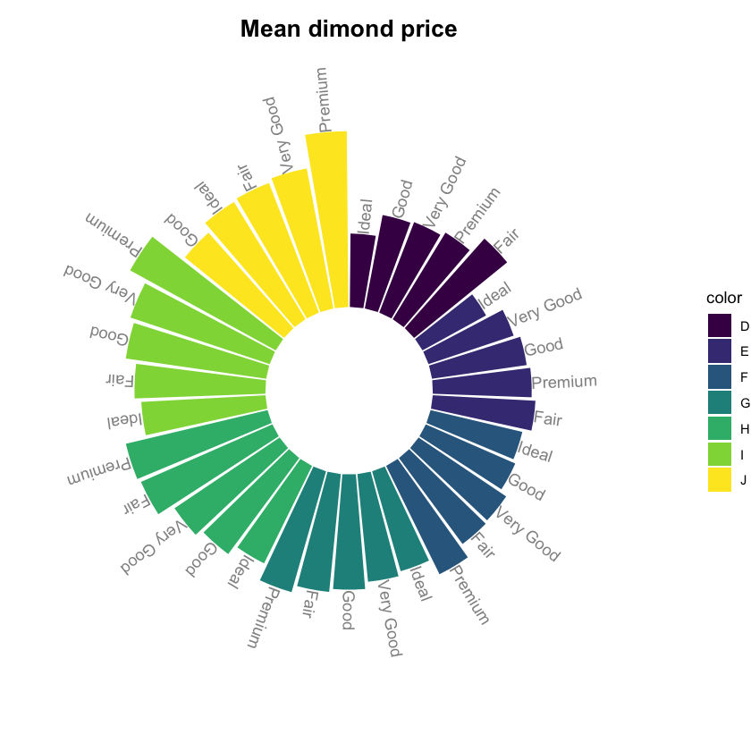

```r
diamonds2plot  %>%
  ggplot(aes(factor(id), price, fill = color, group = cut, label = cut)) +
  geom_bar(stat = 'identity', position = 'dodge') +
  geom_text(hjust = 0, angle = diamonds2plot$angle, alpha = .5) +
  coord_polar() +
  ggtitle('Mean dimond price') +
  ylim(-3000, 7000) +
  theme_void() +
  theme(plot.title = element_text(hjust = 0.5, size = 16, face = 'bold'))
```